# Homework5

Dima Mikhaylov

10/5/2021

## Question 1:

Why do we transform the response variable when the constant variance assumption is not met, instead of transforming the predictor variable?

#### Comment: Variance of response actually only depends on the variance of the error terms, because all other parameters are fixed in the estimation process. Therefore, transforming the response variable is used to mitigate non-constant variance problem, because it effectively changes how sensitive is the respose to the variability in the data. Generally, transforming response using a concave function such as `log()` or `sqrt()` should work well.

## Question 2:

```r
library(faraway)
data(cornnit)
head(cornnit)
```

```
##   yield nitrogen
## 1   115        0
## 2   128       75
## 3   136      150
## 4   135      300
## 5    97        0
## 6   150       75
```

1. What is the response variable and predictor for this study? Create a scatterplot of the data, and interpret the scatterplot

```r
library(tidyverse)
```

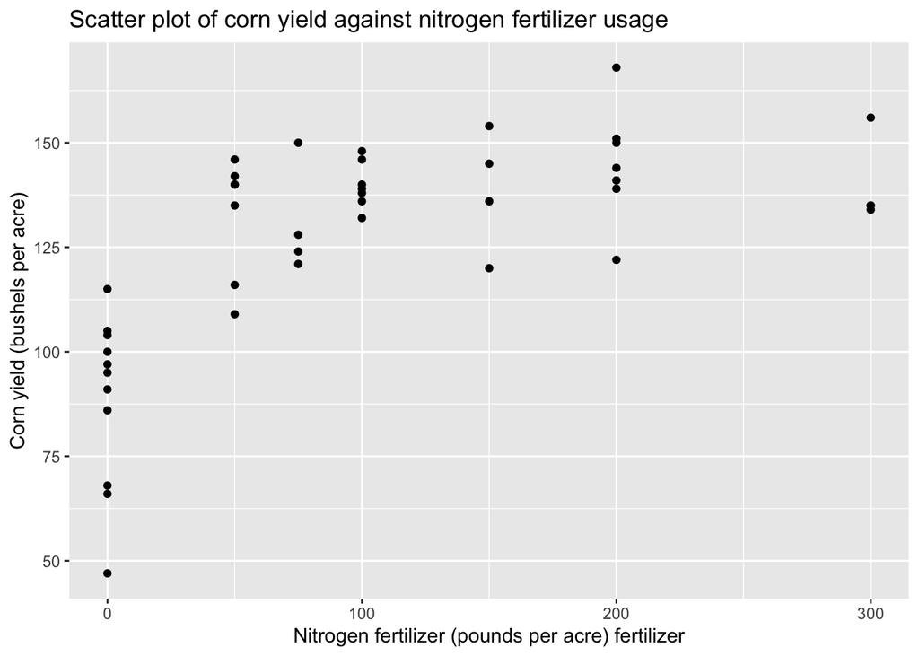

```r
ggplot(cornnit, aes(x=nitrogen, y=yield))+
  geom_point()+
  labs(x="Nitrogen fertilizer (pounds per acre) fertilizer",
       y="Corn yield (bushels per acre)",
       title="Scatter plot of corn yield against nitrogen fertilizer usage")
```

#### Comments: corn yeild is the response (y), and fertilizer usage is the predictor (x). Overall, there seems to be some sort of reltionship between the variables, however it is probably not a linear relationship.

2. Fit a linear regression without any transformations. Create the corresponding residual plot. Based only on the residual plot, what transformation will you consider first? Be sure to explain your reason.

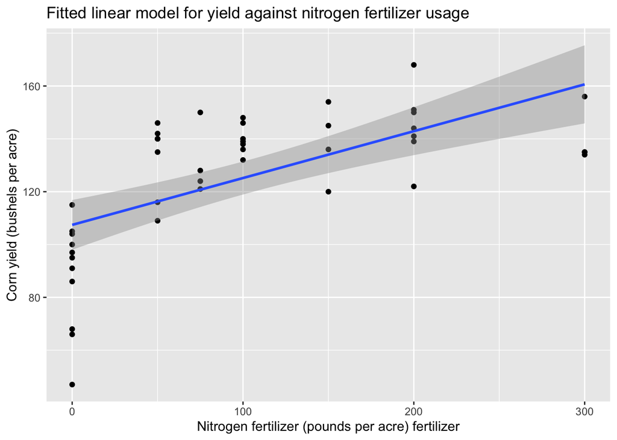

```r
ggplot(cornnit, aes(x=nitrogen, y=yield))+
  geom_point()+
  geom_smooth(method = "lm", se = TRUE)+
  labs(x="Nitrogen fertilizer (pounds per acre) fertilizer",
       y="Corn yield (bushels per acre)",
       title="Fitted linear model for yield against nitrogen fertilizer usage")
```

#### It seems that variance is affecting confidence bounds for the smaller x values, as well as for the larger x valuess. For the former observations the reason could be related to several outliers, extremely low yields recorded at zero nitrogen usage. For the later, very high nitrogen usage, variance of yields may be increasing simply due to a larger value of yield.

```r
base_model = lm(yield ~ nitrogen, data=cornnit)
summary(base_model)
```

```
##
## Call:
## lm(formula = yield ~ nitrogen, data = cornnit)
##
## Residuals:
##     Min      1Q  Median      3Q     Max
## -60.439 -10.939   1.534  14.082  29.697
##
## Coefficients:
##              Estimate Std. Error t value Pr(>|t|)
## (Intercept) 107.43864    4.66622   23.02  < 2e-16 ***
## nitrogen      0.17730    0.03377    5.25 4.71e-06 ***
## ---
## Signif. codes:  0 '***' 0.001 '**' 0.01 '*' 0.05 '.' 0.1 ' ' 1
##
## Residual standard error: 20.53 on 42 degrees of freedom
## Multiple R-squared:  0.3962, Adjusted R-squared:  0.3818
## F-statistic: 27.56 on 1 and 42 DF,  p-value: 4.713e-06
```

#### The summary output confirms some relationship with significant F-statistic, but poor R-squared. Additional analysis of residuals would be needed to confirm linearity of this relationship, i.e. confirm the true predictive power of the model.

Create the corresponding residual plot.

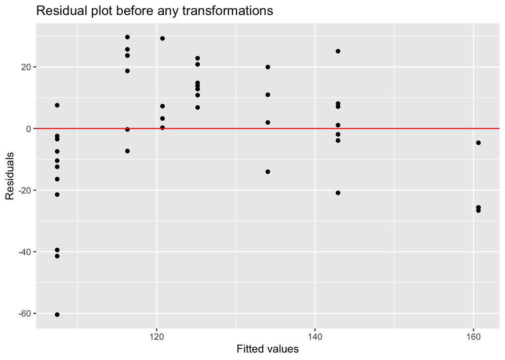

```r
y_fitted <- base_model$fitted.values
residuals <- base_model$residuals
cornnit <- data.frame(cornnit, y_fitted, residuals)

ggplot(cornnit, aes(x=y_fitted, y=residuals))+
  geom_point()+
  geom_hline(yintercept = 0, color='red')+
  labs(x="Fitted values", y="Residuals", title= "Residual plot before any transformations")
```

Based only on the residual plot, what transformation will you consider first? Be sure to explain your reason.

#### Comment: based on the Residual plot, it seems errors may be following a certain pattern. Errors need to be i.i.d and on the Residual plot this should result in points being randomly scattered, i.e. 1) not displaying any pattern (mean 0), and 2) spread of residuals for each fitted value of x should be constant (constant variance). In this case, it is hard to tell about non-constant variance, but non-zero mean is obviously present, as some observations are clustered below the zero line and some are clearly grouped above the zero line. Additional checks for auto-correlation may be warranted.

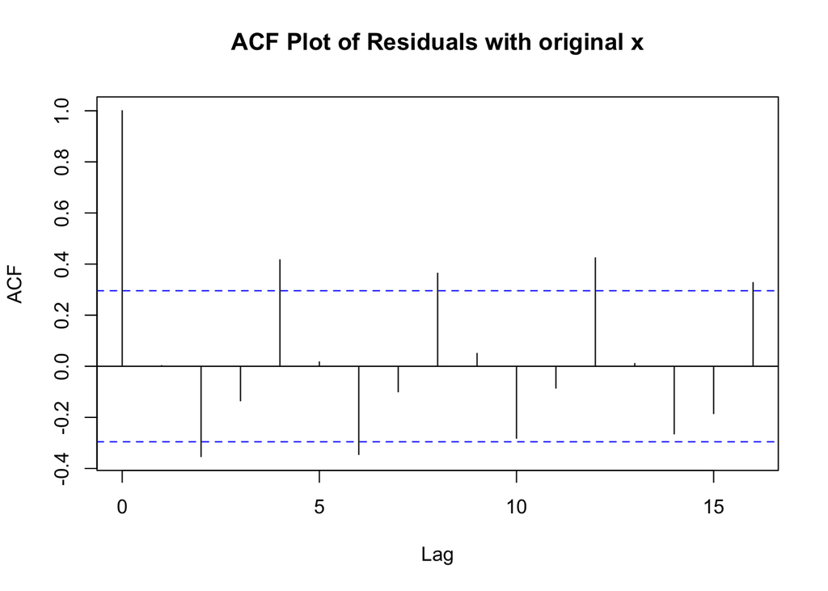

```r
acf(residuals, main="ACF Plot of Residuals with original x")
```